# Lecture 15 Instrumental Variables

Nick Huntington-Klein

March 20, 2019

## Recap

- We’ve covered quite a few methods for isolating causal effects!
- Controlling for variables to close back doors (explain X and Y with the control, remove what’s explained)
- Matching on variables to close back doors (find treated and non-treated observations with )
- Using a control group to control for time (before/after difference for treated and untreated, then difference them)
- Using a cutoff to construct a very good control group (treated/untreated difference near a cutoff)

## Today

- We’ve got ONE LAST METHOD to go deep on!
- Today we’ll be covering *instrumental variables*
- The basic idea is that we have some variable - the instrumental variable - that causes `X` but has no other open back doors!

## Natural Experiments

- This calls back to our idea of trying to mimic an experiment without having an experiment. In fact, let’s think about an actual randomized experiment.
- We have some random assignment `R` that determines your `X`. So even though we have back doors between `X` and `Y`, we can identify `X -> Y`

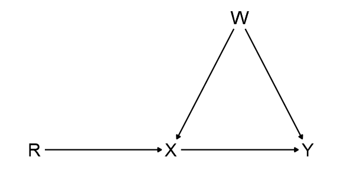

## Natural Experiments

- The idea of instrumental variables is this:
- What if we can find a variable that can take the place of R in the diagram despite not actually being something we randomized in an experiment?
- If we can do that, we’ve clearly got a “natural experiment”
- When we find a variable that can do that, we call it an “instrument” or “instrumental variable”
- Let’s call it `Z`

## Instrumental Variable

So, for `Z` take the place of `R` in the diagram, what do we need?

- `Z` must be related to `X` (typically `Z -> X` but not always)
- There must be *no open paths* from `Z` to `Y` *except for ones that go through `X`*

In other words “`Z` is related to `X`, and all the effect of `Z` on `Y` goes THROUGH `X`”

## Instrumental Variable

- This doesn’t relieve us of the duty of identifying a causal effect by closing back doors
- But it *moves* that duty from the endogenous variable to the instrument, which potentially is easier to identify
- (and then adds on the additional requirement that there are also no open *front* doors from $Z$ to $Y$ except through $X$ )

## Instrumental Variable

How?

- Explain `X` with `Z`, and keep only what *is* explained, `X'`
- Explain `Y` with `Z`, and keep only what *is* explained, `Y'`
- [If `Z` is logical/binary] Divide the difference in `Y'` between `Z` values by the difference in `X'` between `Z` values
- [If `Z` is not logical/binary] Get the correlation between `X'` and `Y'`

## Estimation

- We will be doing this mostly by hand today (until the end part) but most commonly this is estimated using *two stage least squares*
- We basically just do what we described on the last slide:
1. Use the instruments and controls to explain $X$ in the first stage
2. Use the controls and the predicted (explained) part of $X$ in place of $X$ in the second stage
3. (do some standard error adjustments)

Many ways to do this in R, we’ll be doing 2SLS with `feols()` from **fixest**

## Graphically

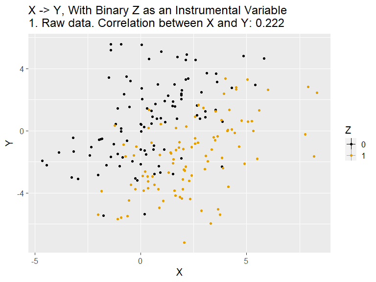

## Instrumental Variables

- Notice that this whole process is like the *opposite* of controlling for a variable
- We explain `X` and `Y` with the variable, but instead of tossing out what’s explained, we ONLY KEEP what’s explained!
- Instead of saying “you’re on a back door, I want to close you” we say “you have no back doors! I want my `X` to be just like you! I’m only keeping that part of `X` that’s explained by you!”
- Since `Z` has no back doors, the part of `X` explained by `Z` has no back doors to the part of `Y` explained by `Z`

## Imperfect Assignment

- Let’s apply one of the common uses of instrumental variables, which actually *is* when you have a randomized experiment
- In normal circumstances, if we have an experiment and assign people with `R`, we just compare `Y` across values of `R`:

```r
df <- tibble(R = sample(c(0,1),500,replace=T)) %>%
  mutate(X = R, Y = 5*X + rnorm(500))
#The truth is a difference of 5
df %>% group_by(R) %>% summarize(Y=mean(Y))
```

```
## # A tibble: 2 x 2
##       R      Y
##   <dbl>  <dbl>
## 1     0 0.0337
## 2     1 4.92
```

## Imperfect Assignment

- But what happens if you run a randomized experiment and assign people with `R`, but not everyone does what you say? Some “treated” people don’t get the treatment, and some “untreated” people do get it
- When this happens, we can’t just compare `Y` across `R`
- But `R` is still a valid instrument!

## Imperfect Assignment

```r
df <- tibble(R = sample(c(0,1),500,replace=T)) %>%
  #We tell them whether or not to get treated
  mutate(X = R) %>%
  #But some of them don't listen! 20% do the OPPOSITE!
  mutate(X = ifelse(runif(500) > .8,1-R,R)) %>%
  mutate(Y = 5*X + rnorm(500))
#The truth is a difference of 5
df %>% group_by(R) %>% summarize(Y=mean(Y))
```

```
## # A tibble: 2 x 2
##       R     Y
##   <dbl> <dbl>
## 1     0  1.07
## 2     1  4.03
```

## Imperfect Assignment

- So let’s do IV (instrumental variables); `R` is the IV.

```r
iv <- df %>% group_by(R) %>% summarize(Y = mean(Y), X = mean(X))
iv
```

```
## # A tibble: 2 x 3
##       R     Y     X
##   <dbl> <dbl> <dbl>
## 1     0  1.07 0.22
## 2     1  4.03 0.824
```

```r
#Remember, since our instrument is binary, we want the slope
(iv$Y[2] - iv$Y[1])/(iv$X[2]-iv$X[1])
```

```
## [1] 4.89457
```

```r
#Truth is 5!
```

## Another Example

- Justifying that an IV has no back doors can be hard!
- Usually things aren’t as clean-cut as having actual randomization
- And sometimes we may have to add controls in order to justify the IV
- Think hard - are there really no other paths from `Z` to `Y`?
- This will often require *detailed contextual knowledge* of the data generating process

## Pollution and Driving

- If air quality is really bad, you may choose to drive instead of walk/bike/bus in order to avoid breathing it
- So do particularly smoggy days lead people to drive more?
- Pan He and Cheng Xu ask this question using Shanghai as an example!

## Pollution and Driving

- Plenty of back doors - seasons, whether factories are running, smog levels last week…

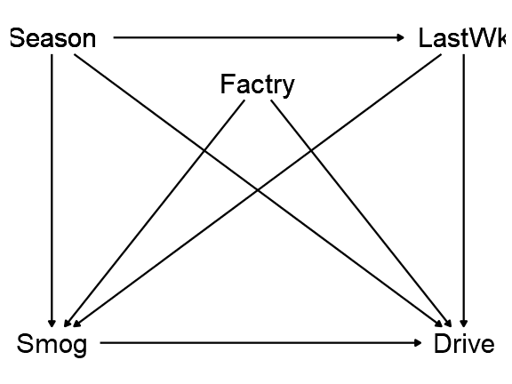

## Pollution and Driving

- The *direction of the wind* could be an IV - Shanghai faces the water, and so when the wind blows West, it brings pollution into the city

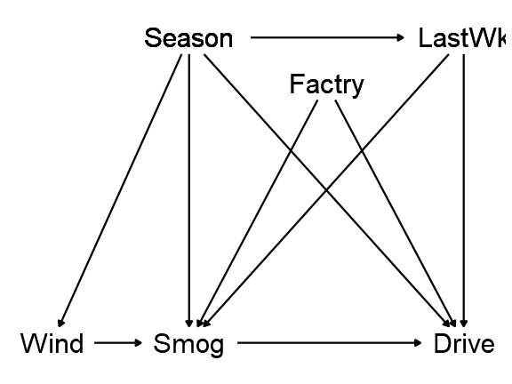

## Pollution and Driving

- This gives us an IV we can use!
- Of course, we need to control for Season to block out the back door.
- The authors do indeed find that additional smog, brought in by the wind, increases the number of people who choose to drive - making the problem worse later!!

## Trade and Manufacturing

- Another example: did Chinese imports reduce US manufacturing employment?
- Employment in the US manufacturing sector has been dropping for decades
- (note - *manufacturing itself* isn’t dropping, we’re manufacturing more than ever, we’re just doing it without as many actual people)

## Trade and Manufacturing

- The timing of the drop in manufacturing jobs coincides with us importing a lot more Chinese stuff
- But did the Chinese imports *cause* the decline or was it a coincidence? Automation is another good explanation!
- Or general declining US competitiveness in the global market, vs. everyone (not just China)

## Trade and Manufacturing

- Autor, Dorn, & Hanson use Chinese exports *to other countries* (`CEXoth`) as an IV for Chinese exports *to the US* (`CEXus`) in order to estimate the impact of Chinese exports *to the US* on US manufacturing employment (`mfg`)
- Let’s think about whether this makes sense as an IV - any back doors from `CEXoth` to `mfg` we can imagine? Or front doors that don’t go through `CEXus`?
- Also, important, do we think that the arrow from `CEXoth` to `CEXus` is actually there?

## Trade and Manufacturing

`D` is global demand for US manufactures, `L` is US labor supply, `Close` measures how similar the kinds of things the US manufactures are to China manufactures

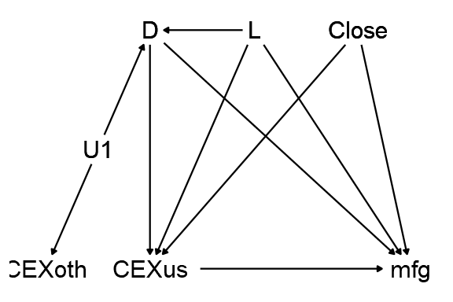

## Trade and Manufacturing

- So we need to control for `D` in some way to close `CEXoth <- U1 -> D -> mfg` but other than that we have a good instrument
- (they do this, and also use information like “what does `Close` look like on a regional level?” to improve their estimate)
- Autor, Dorn, & Hanson found that Chinese exports elsewhere predicted them in the US (China was opening up and becoming more effective as a producer, making their products attractive everywhere)

## Trade and Manufacturing

- And when you limit `mfg` and `CEXus` to just what’s explained by `CEXoth`, you do see that some decline in `mfg` is because of Chinese imports

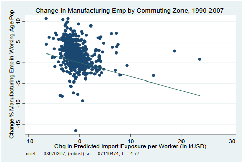

Direct effect of instruments on `mfg`

## Practice

- Does the price of cigarettes affect smoking? Get AER package and data(CigarettesSW). Examine with help().
- Get JUST thecigarette taxes `cigtax` from `taxs-tax`
- Draw a causal diagram using `packs`, `price`, `cigtax`, and some back door `W`. What might `W` be?
- Adjust `price` and `cigtax` for inflation: divide them by `cpi`
- Explain `price` and `packs` with `cigtax` using `cut(,breaks=7)` for `cigtax`
- Get correlation between the explained parts and plot the explained parts - does price reduce packs smoked?

## Practice Answers

```r
library(AER)
data(CigarettesSW)

CigarettesSW <- CigarettesSW %>%
  mutate(cigtax = taxs-tax) %>%
  mutate(price = price/cpi,
         cigtax = cigtax/cpi) %>%
  group_by(cut(cigtax,breaks=7)) %>%
  summarize(priceexp = mean(price),
         packsexp = mean(packs)) %>%
  ungroup()

cor(CigarettesSW$priceexp,CigarettesSW$packsexp)
```

```
## [1] -0.9711096
```

## Practice Answers Plot

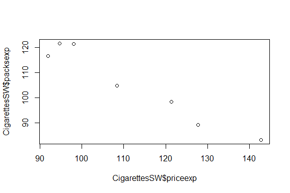

```r
plot(CigarettesSW$priceexp,CigarettesSW$packsexp)
```

## Practice Diagram Answers

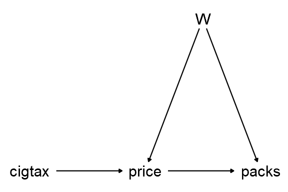

## Practice - Doing it with Regression!

- Common 2SLS estimators: `ivreg` in **AER**, `iv_robust` in **estimatr**, and `feols()` in **fixest**. We’ll use the latter since it’s fast easy to combine with fixed effects and all kinds of error adjustments

```r
m <- feols(Y ~ controls | X ~ Z, data = data)
m <- feols(Y ~ controls | fixed_effects | X ~ Z, data = data, se = 'hetero')
```

## Practice - Doing it with Regression

- Reload the cigarette data and skip the summarize step
- Run our cigarette analysis first doing 2SLS by hand - use `lm()` to run the first stage, then replace `price` with `predict(m)` in the second stage
- Then use `feols()` to do the same (use 1 to indicate no controls). Coefficients should be the same but the standard errors will be corrected in the `feols()` version!
- Show both results in `msummary()`

## Practice - Doing it with Regression

```r
data(CigarettesSW)

CigarettesSW <- CigarettesSW %>%
  mutate(cigtax = taxs-tax) %>%
  mutate(price = price/cpi,
         cigtax = cigtax/cpi)
first_stage <- lm(price~cigtax, data = CigarettesSW)
second_stage <- lm(packs ~ predict(first_stage), data = CigarettesSW)
package <- feols(packs ~ 1 | price ~ cigtax, data = CigarettesSW)
```

## Practice - Doing it with Regression

```r
msummary(list(second_stage, package), stars = TRUE, gof_omit = 'AIC|BIC|Lik|F|R2')
```

|  | Model 1 | Model 2 |
| --- | --- | --- |
| (Intercept) | 219.576*** | 219.576*** |
|  | (20.863) | (16.989) |
| predict(first_stage) | -1.019*** |  |
|  | (0.191) |  |
| fit_price |  | -1.019*** |
|  |  | (0.156) |
| Num.Obs. | 96 | 96 |
| Std. errors |  | Standard |

* p < 0.1, ** p < 0.05, *** p < 0.01